# Ford GoBike System Data

## Preliminary Wrangling

> The dataset is about LA from Jan 2019 to Dec 2019. The dataset consists of four La csv files which are divided into 4 quaters. **station.csv** consists of station name in LA. The columns in LA dataset are -
> 1. **trip-id**- unique id of the trip
> 2. **Duration**- duration of the trip in minutes
> 3. **start_time**- start date and time of the trip
> 4. **start_station**- start station id of the trip
> 5. **start_lat**- the latitude of the start station
> 6. **start_lon**- the longitude of the start station
> 7. **end_station**- end station id
> 8. **end_lat**- the latitude of the end station
> 9. **end_lon**- the longitude of the end station
> 10. **bike_id**- Locally unique integer that identifies the bike
> 11. **plan_duration**- The number of days that the plan the passholder is using entitles them to ride; 0 is used for a single ride plan (Walk-up)
> 12. **trip_route_category**- "Round Trip" for trips starting and ending at the same station or "One Way" for all other trips
> 13. **passholder_type**- the passes which user holds
> 14. **bike_type**- The kind of bike used on the trip, including standard pedal-powered bikes, electric assist bikes, or smart bikes.

```python
# import all packages and set plots to be embedded inline
import numpy as np
import pandas as pd
import matplotlib.pyplot as plt
import seaborn as sb
import calendar
import plotly as px
import math
%matplotlib inline
```

```python
la1=pd.read_csv("LA-q1.csv")
la2=pd.read_csv("LA-q2.csv")
la3=pd.read_csv("LA-q3.csv")
la4=pd.read_csv("LA-q4.csv")
station=pd.read_csv("stations.csv")
```

```python
data=pd.concat([la1,la2,la3,la4])
```

```python
data[:3]
```

|  | trip_id | duration | start_time | end_time | start_station | start_lat | start_lon | end_station | end_lat | end_lon | bike_id | plan_duration | trip_route_category | passholder_type | bike_type |
| --- | --- | --- | --- | --- | --- | --- | --- | --- | --- | --- | --- | --- | --- | --- | --- |
| 0 | 112536773 | 7 | 2019-01-01 00:07:00 | 2019-01-01 00:14:00 | 3046 | 34.052872 | -118.24749 | 3051 | 34.045422 | -118.253517 | 06468 | 1 | One Way | Walk-up | standard |
| 1 | 112536772 | 6 | 2019-01-01 00:08:00 | 2019-01-01 00:14:00 | 3046 | 34.052872 | -118.24749 | 3051 | 34.045422 | -118.253517 | 12311 | 1 | One Way | Walk-up | standard |
| 2 | 112538689 | 32 | 2019-01-01 00:18:00 | 2019-01-01 00:50:00 | 3030 | 34.051941 | -118.24353 | 3075 | 34.042110 | -118.256187 | 05992 | 1 | One Way | Walk-up | standard |

```python
station[:5]
```

|  | Station_ID | Station_Name | Day of Go_live_date | Region | Status |
| --- | --- | --- | --- | --- | --- |
| 0 | 3000 | Virtual Station | 7/7/2016 | NaN | Active |
| 1 | 3005 | 7th & Flower | 7/7/2016 | DTLA | Active |
| 2 | 3006 | Olive & 8th | 7/7/2016 | DTLA | Active |
| 3 | 3007 | 5th & Grand | 7/7/2016 | DTLA | Active |
| 4 | 3008 | Figueroa & 9th | 7/7/2016 | DTLA | Active |

```python
data=data.rename(columns={'start_station':'Station_ID'})
```

```python
#merging the la and station dataset
data=data.merge(station,on='Station_ID')
```

```python
data[:5]
```

|  | trip_id | duration | start_time | end_time | Station_ID | start_lat | start_lon | end_station | end_lat | end_lon | bike_id | plan_duration | trip_route_category | passholder_type | bike_type | Station_Name | Day of Go_live_date | Region | Status |
| --- | --- | --- | --- | --- | --- | --- | --- | --- | --- | --- | --- | --- | --- | --- | --- | --- | --- | --- | --- |
| 0 | 112536773 | 7 | 2019-01-01 00:07:00 | 2019-01-01 00:14:00 | 3046 | 34.052872 | -118.24749 | 3051 | 34.045422 | -118.253517 | 06468 | 1 | One Way | Walk-up | standard | 2nd & Hill | 7/12/2016 | DTLA | Active |
| 1 | 112536772 | 6 | 2019-01-01 00:08:00 | 2019-01-01 00:14:00 | 3046 | 34.052872 | -118.24749 | 3051 | 34.045422 | -118.253517 | 12311 | 1 | One Way | Walk-up | standard | 2nd & Hill | 7/12/2016 | DTLA | Active |
| 2 | 112539166 | 19 | 2019-01-01 00:45:00 | 2019-01-01 01:04:00 | 3046 | 34.052872 | -118.24749 | 4220 | 34.074829 | -118.258728 | 05944 | 1 | One Way | Walk-up | standard | 2nd & Hill | 7/12/2016 | DTLA | Active |
| 3 | 112539165 | 18 | 2019-01-01 00:46:00 | 2019-01-01 01:04:00 | 3046 | 34.052872 | -118.24749 | 4220 | 34.074829 | -118.258728 | 05782 | 1 | One Way | Walk-up | standard | 2nd & Hill | 7/12/2016 | DTLA | Active |
| 4 | 112543295 | 13 | 2019-01-01 02:15:00 | 2019-01-01 02:28:00 | 3046 | 34.052872 | -118.24749 | 3018 | 34.043732 | -118.260139 | 06717 | 1 | One Way | Walk-up | standard | 2nd & Hill | 7/12/2016 | DTLA | Active |

```python
# droping the start_lat, start_lon, end_lat and end_lon columns
data.drop(['start_lat','start_lon','end_lat','end_lon','Region '], axis=1, inplace= True)
```

```python
# Print the details of LA
print(data.shape)
print("")
print(data.dtypes)
print(data.head(5))
```

```
(290309, 14)

trip_id                 int64
duration                int64
start_time             object
end_time               object
Station_ID              int64
end_station             int64
bike_id                object
plan_duration           int64
trip_route_category    object
passholder_type        object
bike_type              object
Station_Name           object
Day of Go_live_date    object
Status                 object
dtype: object
     trip_id  duration           start_time             end_time  Station_ID  \
0  112536773         7  2019-01-01 00:07:00  2019-01-01 00:14:00        3046
1  112536772         6  2019-01-01 00:08:00  2019-01-01 00:14:00        3046
2  112539166        19  2019-01-01 00:45:00  2019-01-01 01:04:00        3046
3  112539165        18  2019-01-01 00:46:00  2019-01-01 01:04:00        3046
4  112543295        13  2019-01-01 02:15:00  2019-01-01 02:28:00        3046

   end_station bike_id  plan_duration trip_route_category passholder_type  \
0         3051   06468              1             One Way         Walk-up
1         3051   12311              1             One Way         Walk-up
2         4220   05944              1             One Way         Walk-up
3         4220   05782              1             One Way         Walk-up
4         3018   06717              1             One Way         Walk-up

  bike_type Station_Name Day of Go_live_date  Status
0  standard   2nd & Hill           7/12/2016  Active
1  standard   2nd & Hill           7/12/2016  Active
2  standard   2nd & Hill           7/12/2016  Active
3  standard   2nd & Hill           7/12/2016  Active
4  standard   2nd & Hill           7/12/2016  Active
```

```python
#making a separate column for year,month,day
data['start_time'] = pd.to_datetime(data['start_time'])
data['start_year']= data['start_time'].dt.year
data['start_month']=data['start_time'].dt.month
data['start_day']=data['start_time'].dt.day
data[:3]
```

|  | trip_id | duration | start_time | end_time | Station_ID | end_station | bike_id | plan_duration | trip_route_category | passholder_type | bike_type | Station_Name | Day of Go_live_date | Status | start_year | start_month | start_day |
| --- | --- | --- | --- | --- | --- | --- | --- | --- | --- | --- | --- | --- | --- | --- | --- | --- | --- |
| 0 | 112536773 | 7 | 2019-01-01 00:07:00 | 2019-01-01 00:14:00 | 3046 | 3051 | 06468 | 1 | One Way | Walk-up | standard | 2nd & Hill | 7/12/2016 | Active | 2019 | 1 | 1 |
| 1 | 112536772 | 6 | 2019-01-01 00:08:00 | 2019-01-01 00:14:00 | 3046 | 3051 | 12311 | 1 | One Way | Walk-up | standard | 2nd & Hill | 7/12/2016 | Active | 2019 | 1 | 1 |
| 2 | 112539166 | 19 | 2019-01-01 00:45:00 | 2019-01-01 01:04:00 | 3046 | 4220 | 05944 | 1 | One Way | Walk-up | standard | 2nd & Hill | 7/12/2016 | Active | 2019 | 1 | 1 |

```python
data['start_hour'] = data['start_time'].apply(lambda time: time.hour)
data['period_day'] = 'morning'
data['period_day'][(data['start_hour'] >= 12) & (data['start_hour'] <= 17)] = 'afternoon'
data['period_day'][(data['start_hour'] >= 18) & (data['start_hour'] <= 23)] = 'night'
```

```python
data.period_day.value_counts()
```

```
afternoon    129808
morning       87072
night         73429
Name: period_day, dtype: int64
```

```python
data['seasons']='Winter'
data['seasons'][(data['start_month'] >= 3) & (data['start_month'] <= 5)]='Spring'
data['seasons'][(data['start_month'] >=6) & (data['start_month'] <= 8)]='Summer'
data['seasons'][(data['start_month'] >=9) & (data['start_month'] <= 11)]='Autumn'
```

```python
data.seasons.value_counts()
```

```
Summer    88219
Autumn    84984
Spring    58576
Winter    58530
Name: seasons, dtype: int64
```

```python
data['week_num'] = data['start_time'].apply(lambda time: time.dayofweek)
d = {0:'Mon',1:'Tue',2:'Wed',3:'Thu',4:'Fri',5:'Sat',6:'Sun'}
data['week_name'] = data['week_num'].map(d)
```

```python
data.week_num.value_counts()
```

```
4    45480
1    45245
3    43820
2    41850
0    41826
6    36352
5    35736
Name: week_num, dtype: int64
```

```python
data.week_name.value_counts()
```

```
Fri    45480
Tue    45245
Thu    43820
Wed    41850
Mon    41826
Sun    36352
Sat    35736
Name: week_name, dtype: int64
```

```python
# converting the month number to month name
data['start_month'] = data['start_month'].apply(lambda x: calendar.month_abbr[x])
```

```python
data['Station_Name'].value_counts()
```

```
7th & Flower                                              14186
Main & 1st                                                13172
Union Station West Portal                                 10975
7th & Spring                                               8807
Ocean Front Walk & Navy                                    8424
                                                          ...
Santa Monica & Virgil                                        13
Del Rey Day Pop-up                                           12
Pop-up Station at CicLAvia Culver City Hub                   12
Public Bike Rack: Westwood/Rancho Park Expo Line North        3
Figueroa & 4th                                                1
Name: Station_Name, Length: 218, dtype: int64
```

```python
data.isnull().sum()
```

```
trip_id                0
duration               0
start_time             0
end_time               0
Station_ID             0
end_station            0
bike_id                0
plan_duration          0
trip_route_category    0
passholder_type        0
bike_type              0
Station_Name           0
Day of Go_live_date    0
Status                 0
start_year             0
start_month            0
start_day              0
start_hour             0
period_day             0
seasons                0
week_num               0
week_name              0
dtype: int64
```

```python
data.info()
```

```
<class 'pandas.core.frame.DataFrame'>
Int64Index: 290309 entries, 0 to 290308
Data columns (total 22 columns):
 #   Column               Non-Null Count   Dtype
---  ------               --------------   -----
 0   trip_id              290309 non-null  int64
 1   duration             290309 non-null  int64
 2   start_time           290309 non-null  datetime64[ns]
 3   end_time             290309 non-null  object
 4   Station_ID           290309 non-null  int64
 5   end_station          290309 non-null  int64
 6   bike_id              290309 non-null  object
 7   plan_duration        290309 non-null  int64
 8   trip_route_category  290309 non-null  object
 9   passholder_type      290309 non-null  object
 10  bike_type            290309 non-null  object
 11  Station_Name         290309 non-null  object
 12  Day of Go_live_date  290309 non-null  object
 13  Status               290309 non-null  object
 14  start_year           290309 non-null  int64
 15  start_month          290309 non-null  object
 16  start_day            290309 non-null  int64
 17  start_hour           290309 non-null  int64
 18  period_day           290309 non-null  object
 19  seasons              290309 non-null  object
 20  week_num             290309 non-null  int64
 21  week_name            290309 non-null  object
dtypes: datetime64[ns](1), int64(9), object(12)
memory usage: 50.9+ MB
```

```python
data[:5]
```

|  | trip_id | duration | start_time | end_time | Station_ID | end_station | bike_id | plan_duration | trip_route_category | passholder_type | ... | Day of Go_live_date | Status | start_year | start_month | start_day | start_hour | period_day | seasons | week_num | week_name |
| --- | --- | --- | --- | --- | --- | --- | --- | --- | --- | --- | --- | --- | --- | --- | --- | --- | --- | --- | --- | --- | --- |
| 0 | 112536773 | 7 | 2019-01-01 00:07:00 | 2019-01-01 00:14:00 | 3046 | 3051 | 06468 | 1 | One Way | Walk-up | ... | 7/12/2016 | Active | 2019 | Jan | 1 | 0 | morning | Winter | 1 | Tue |
| 1 | 112536772 | 6 | 2019-01-01 00:08:00 | 2019-01-01 00:14:00 | 3046 | 3051 | 12311 | 1 | One Way | Walk-up | ... | 7/12/2016 | Active | 2019 | Jan | 1 | 0 | morning | Winter | 1 | Tue |
| 2 | 112539166 | 19 | 2019-01-01 00:45:00 | 2019-01-01 01:04:00 | 3046 | 4220 | 05944 | 1 | One Way | Walk-up | ... | 7/12/2016 | Active | 2019 | Jan | 1 | 0 | morning | Winter | 1 | Tue |
| 3 | 112539165 | 18 | 2019-01-01 00:46:00 | 2019-01-01 01:04:00 | 3046 | 4220 | 05782 | 1 | One Way | Walk-up | ... | 7/12/2016 | Active | 2019 | Jan | 1 | 0 | morning | Winter | 1 | Tue |
| 4 | 112543295 | 13 | 2019-01-01 02:15:00 | 2019-01-01 02:28:00 | 3046 | 3018 | 06717 | 1 | One Way | Walk-up | ... | 7/12/2016 | Active | 2019 | Jan | 1 | 2 | morning | Winter | 1 | Tue |

5 rows × 22 columns

### What is the structure of your dataset?

(290309, 22)

### What is/are the main feature(s) of interest in your dataset?

> My main interest in dataset is that to see the user behaviour. How many types of passes are there? Which time is the most busiest for users? Which bike types are more popular? Which month and week day is the busiest?

### What features in the dataset do you think will help support your investigation into your feature(s) of interest?

> The month names and the week days will support my investigation.

## Univariate Exploration

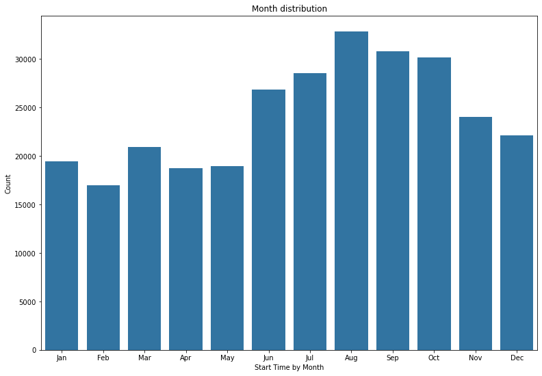

```python
# by month
plt.figure(figsize=(13,9))
base_color = sb.color_palette()[0]
sb.countplot(data=data, x='start_month',color=base_color)
plt.xlabel('Start Time by Month')
plt.ylabel('Count')
plt.title('Month distribution');
```

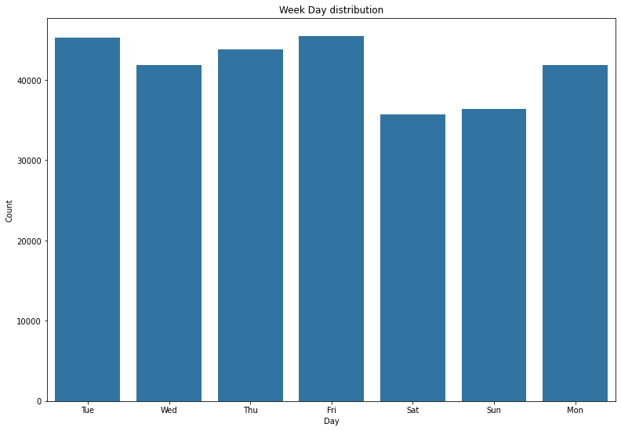

```python
# By Day
plt.figure(figsize=(13,9))

sb.countplot(data=data, x='week_name',color=base_color)
plt.xlabel('Day')
plt.ylabel('Count')
plt.title('Week Day distribution');
```

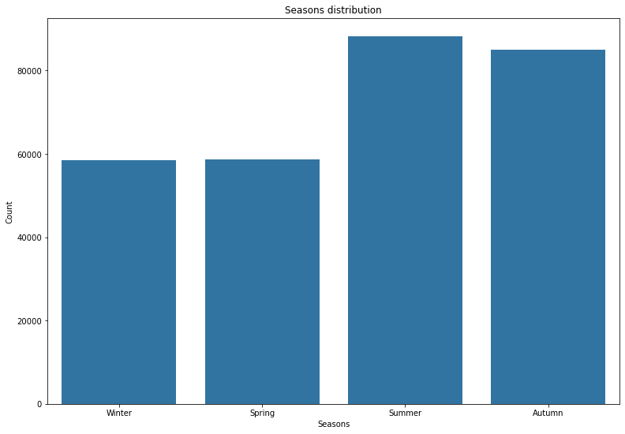

```python
# By seasons
plt.figure(figsize=(13,9))
sb.countplot(data=data,x='seasons',color=base_color)
plt.xlabel('Seasons')
plt.ylabel('Count')
plt.title('Seasons distribution');
```

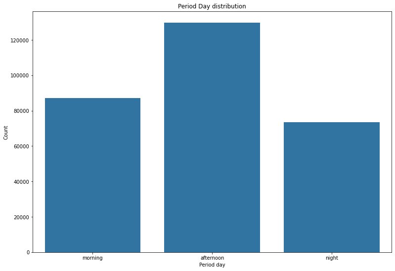

```python
# By time of day
plt.figure(figsize=(13,9))
sb.countplot(data=data,x='period_day',color=base_color)
plt.xlabel('Period day')
plt.ylabel('Count')
plt.title('Period Day distribution')
```

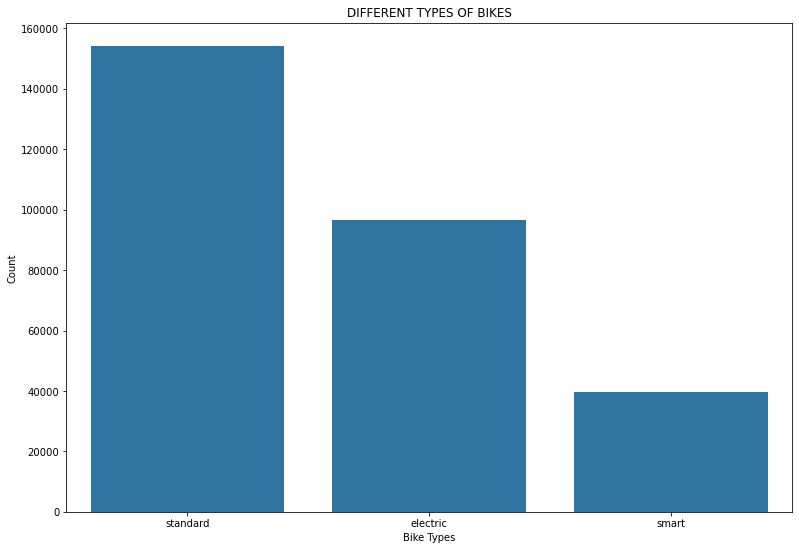

```python
#bike type
plt.figure(figsize=(13,9))
sb.countplot(data=data,x='bike_type',color=base_color)
plt.xlabel('Bike Types')
plt.ylabel('Count')
plt.title('DIFFERENT TYPES OF BIKES')
```

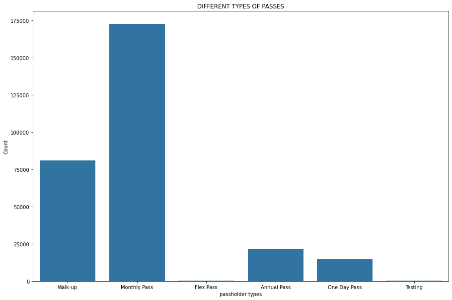

```python
#passholder_type
plt.figure(figsize=(15,10))
sb.countplot(data=data,x='passholder_type',color=base_color)
plt.xlabel('passholder types')
plt.ylabel('Count')
plt.title('DIFFERENT TYPES OF PASSES')
```

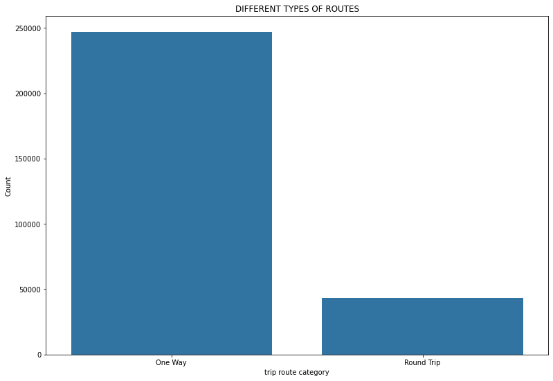

```python
#trip_route_category
plt.figure(figsize=(13,9))
sb.countplot(data=data, x ='trip_route_category',color=base_color)
plt.xlabel('trip route category')
plt.ylabel('Count')
plt.title('DIFFERENT TYPES OF ROUTES')
```

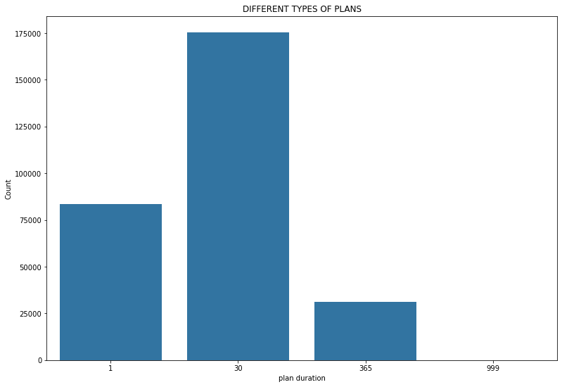

```python
#plan duration
plt.figure(figsize=(13,9))
sb.countplot(data=data, x= 'plan_duration',color=base_color)
plt.xlabel('plan duration')
plt.ylabel('Count')
plt.title('DIFFERENT TYPES OF PLANS')
```

```python
trip_by_hour_df = data.groupby('start_hour').agg({'bike_id':'count'}).reset_index()
```

```python
trip_by_hour_df['bike_id'] = (trip_by_hour_df['bike_id']/trip_by_hour_df['bike_id'].sum())*100
```

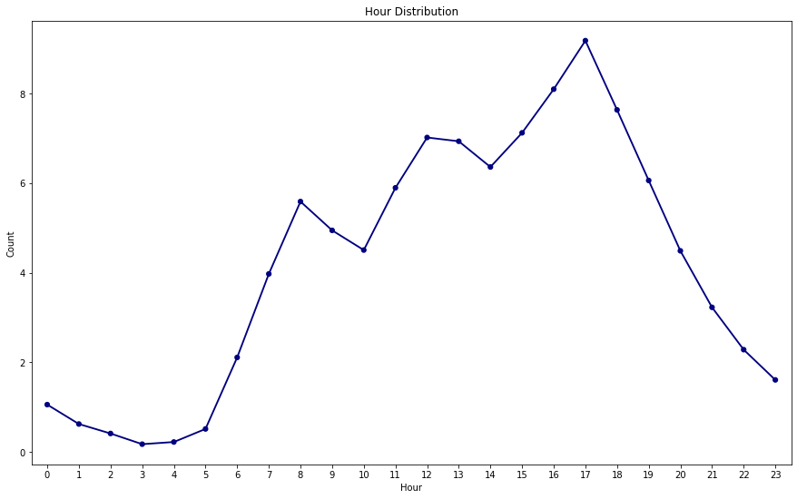

```python
plt.figure(figsize=(15,9))
sb.pointplot(x='start_hour', y='bike_id', scale=.7, color='navy', data=trip_by_hour_df)
plt.xlabel('Hour')
plt.ylabel('Count')
plt.title('Hour Distribution');
```

### CONCLUSION

> It is observed that August was highest trips were done and on Friday. There were many Monthly pass compared to other passes. I wanted to further investigate that which bike is more popular in which month and average duration trips taken with different kinds of bikes. Mostly around 17:00-18:00 hours were most trips taken. What would be average duration of different passholder types? What would be the average duration of bike types and the average duration of the route category?

### DIFFICULTIES

> There were missing values in start lat, start lon, end lat and end lon. I have dropped those columns. It would have helped if there was distance in the dataset. It would have helped me to understand the user behaviour in depth. for eg- average distance covered by passholders, average distance taken for different bike types.

## Bivariate Exploration

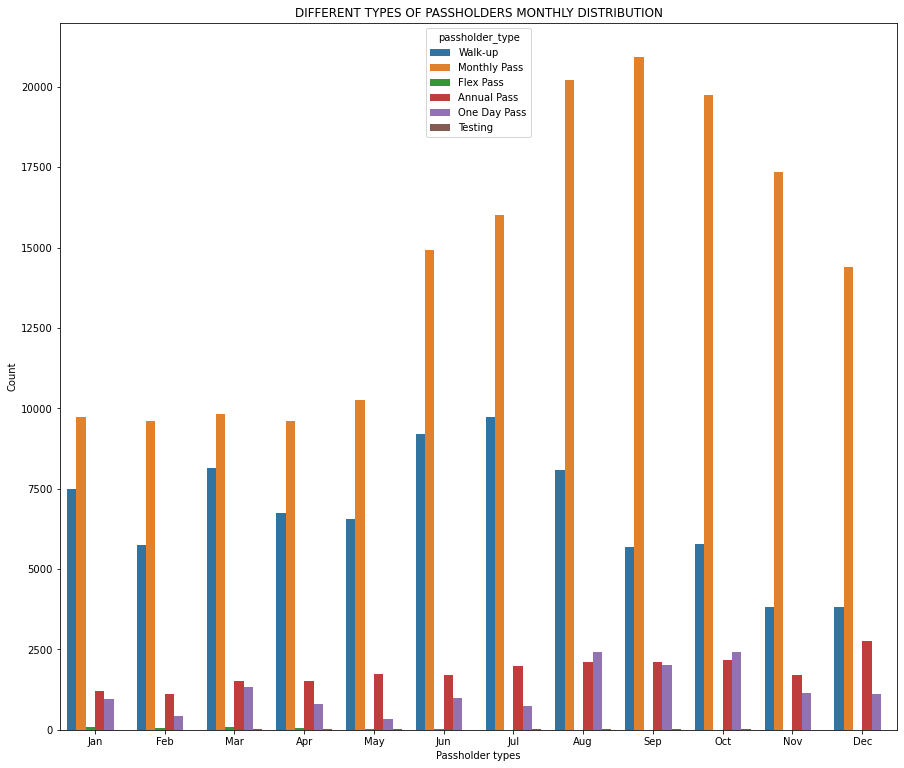

```python
plt.figure(figsize=(15,13))
base_color = sb.color_palette()[0]
sb.countplot(data = data, x = 'start_month', hue = 'passholder_type')
plt.xlabel('Passholder types')
plt.ylabel('Count')
plt.title('DIFFERENT TYPES OF PASSHOLDERS MONTHLY DISTRIBUTION');
```

> It is observed that In September that many monthly passholders trips were taken.

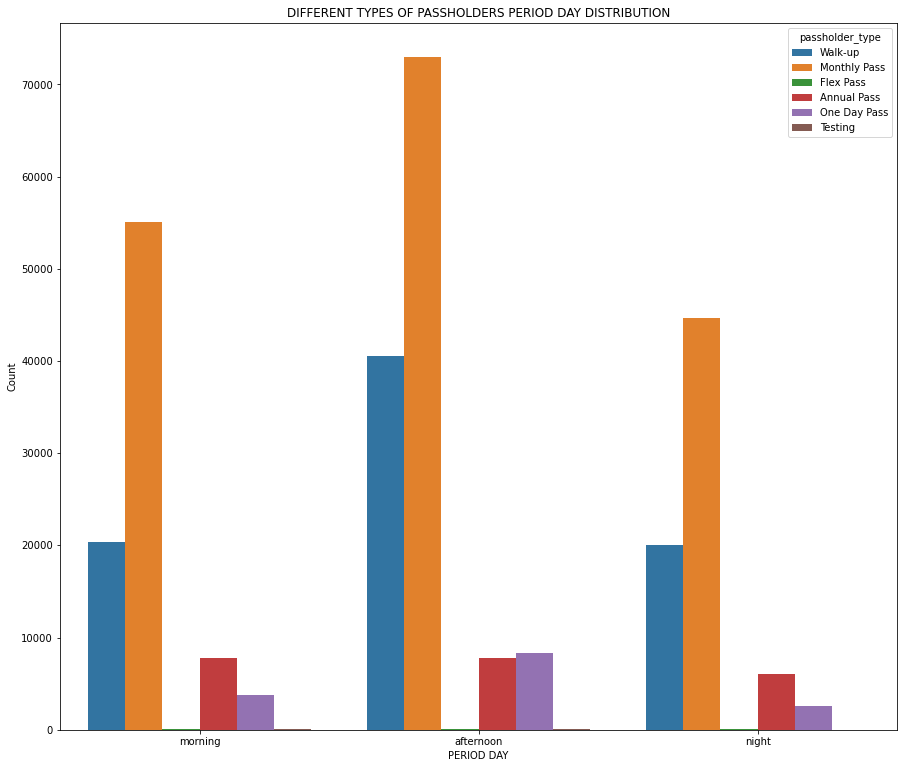

```python
plt.figure(figsize=(15,13))
sb.countplot(data = data, x = 'period_day', hue = 'passholder_type')
plt.xlabel('PERIOD DAY')
plt.ylabel('Count')
plt.title('DIFFERENT TYPES OF PASSHOLDERS PERIOD DAY DISTRIBUTION');
```

> It is observed that afternoon most trips were taken with different kinds of the passholders.

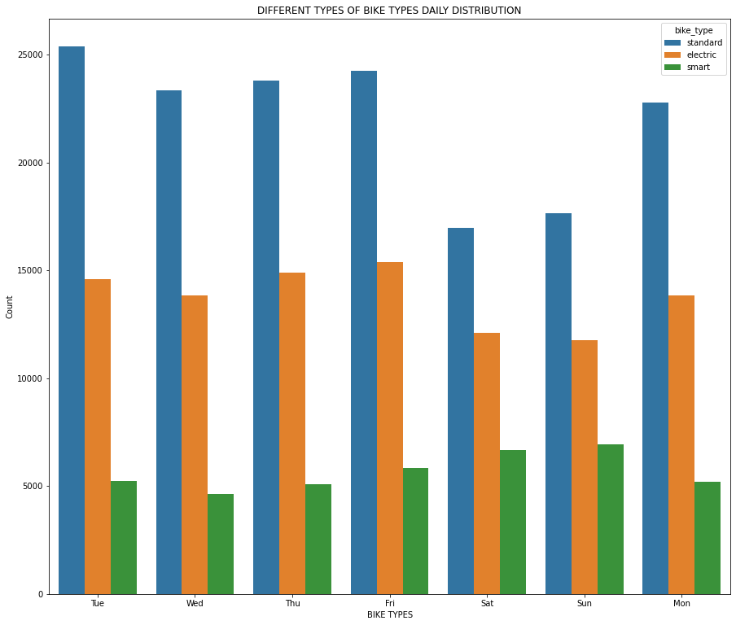

```python
plt.figure(figsize=(15,13))
sb.countplot(data = data, x = 'week_name', hue = 'bike_type')
plt.xlabel('BIKE TYPES')
plt.ylabel('Count')
plt.title('DIFFERENT TYPES OF BIKE TYPES DAILY DISTRIBUTION');
```

> On Tuesday most trips were taken with standard bike.

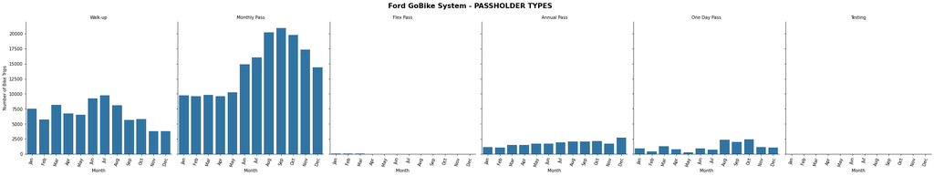

```python
plt.figure(figsize=(15,13))
graph = sb.catplot(data=data, x='start_month', col="passholder_type", kind='count', sharey = True, color = base_color);

graph.set_axis_labels("Month", "Number of Bike Trips");
graph.set_titles("{col_name}");

graph.fig.suptitle('Ford GoBike System - PASSHOLDER TYPES', y=1.05, fontsize=16, fontweight='bold');
graph.set_xticklabels(rotation=75);
```

> This graph helps in better understanding which passholders prefer which month. During September highest trips were taken by Monthly passholder and in July highest trips were taken by walk-up passholder.

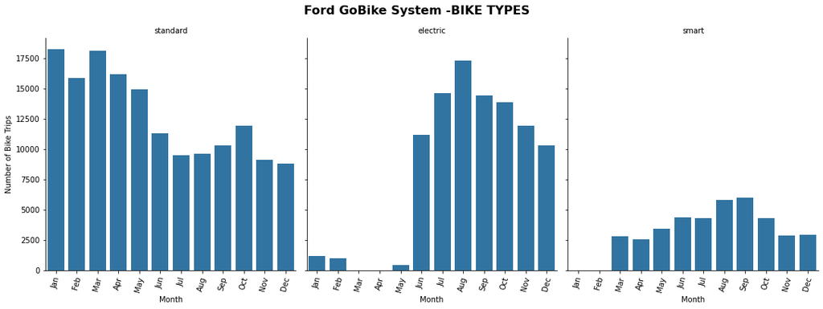

```python
graph = sb.catplot(data=data, x='start_month', col="bike_type", kind='count', sharey = True, color = base_color);

graph.set_axis_labels("Month", "Number of Bike Trips");
graph.set_titles("{col_name}");

graph.fig.suptitle('Ford GoBike System -BIKE TYPES', y=1.05, fontsize=16, fontweight='bold');
graph.set_xticklabels(rotation=75);
```

> In this graph we can see that January is the month where users have taken highest number of trips by standard bike and August is the month where users have prefered electric bikes.

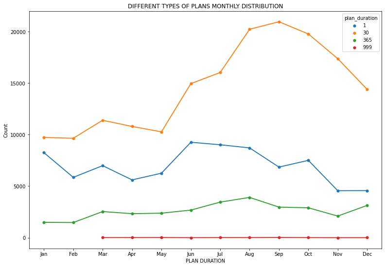

```python
plt.figure(figsize=(13, 9))
user_week = data.groupby(['start_month','plan_duration']).size().reset_index()
days=['Morning','Afternoon','Night']
weekday = ['Mon', 'Tue', 'Wed', 'Thu', 'Fri', 'Sat', 'Sun']
months =['Jan', 'Feb','Mar','Apr', 'May', 'Jun', 'Jul', 'Aug', 'Sep', 'Oct', 'Nov', 'Dec']
sb.pointplot(data=user_week, x='start_month', y=0, hue = 'plan_duration', scale=.7, order = months)
plt.title('DIFFERENT TYPES OF PLANS MONTHLY DISTRIBUTION')
plt.xlabel('PLAN DURATION')
plt.ylabel('Count')
```

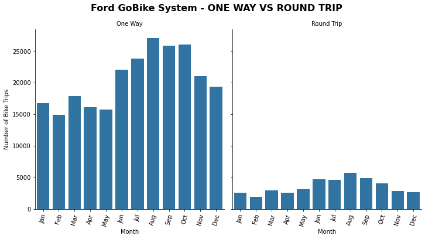

```python
graph = sb.catplot(data=data, x='start_month', col="trip_route_category", kind='count', sharey = True, color = base_color);

graph.set_axis_labels("Month", "Number of Bike Trips");
graph.set_titles("{col_name}");

graph.fig.suptitle('Ford GoBike System - ONE WAY VS ROUND TRIP', y=1.05, fontsize=16, fontweight='bold');
graph.set_xticklabels(rotation=75);
```

> It helps to differentiate the users prefer which route- The round trip or one way on monthly distribution.

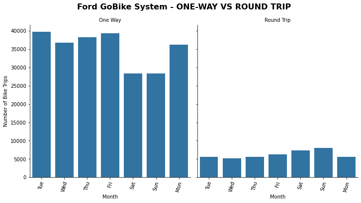

```python
graph = sb.catplot(data=data, x='week_name', col="trip_route_category", kind='count', sharey = True, color = base_color);

graph.set_axis_labels("Month", "Number of Bike Trips");
graph.set_titles("{col_name}");

graph.fig.suptitle('Ford GoBike System - ONE-WAY VS ROUND TRIP', y=1.05, fontsize=16, fontweight='bold');
graph.set_xticklabels(rotation=75);
```

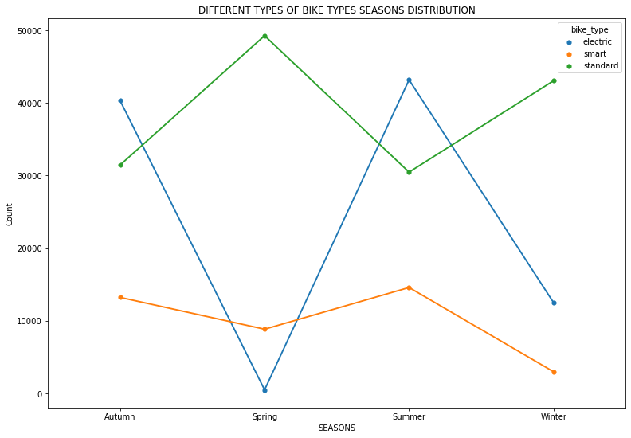

```python
plt.figure(figsize=(13, 9))
user_week = data.groupby(['seasons','bike_type']).size().reset_index()
sb.pointplot(data=user_week, x='seasons', y=0, hue = 'bike_type', scale=.7, )
plt.title('DIFFERENT TYPES OF BIKE TYPES SEASONS DISTRIBUTION')
plt.xlabel('SEASONS')
plt.ylabel('Count')
```

> In this line chart electric bike is more preferd during summer and standard bikes are more prefered during spring.

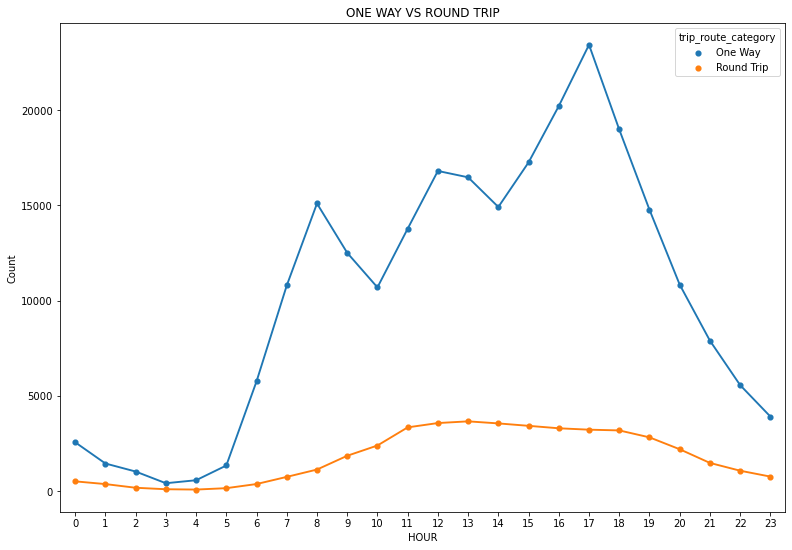

```python
plt.figure(figsize=(13, 9))
user_week = data.groupby(['start_hour','trip_route_category']).size().reset_index()
sb.pointplot(data=user_week, x='start_hour', y=0, hue = 'trip_route_category', scale=.7, )
plt.title('ONE WAY VS ROUND TRIP')
plt.xlabel('HOUR')
plt.ylabel('Count')
```

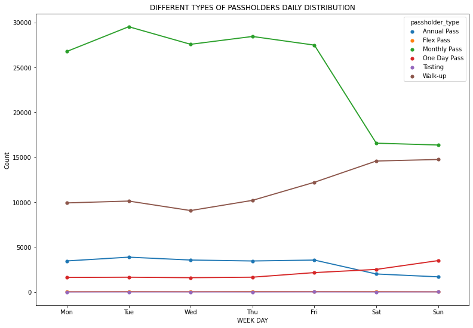

```python
plt.figure(figsize=(13, 9))
user_week = data.groupby(['week_name','passholder_type']).size().reset_index()
weekday = ['Mon', 'Tue', 'Wed', 'Thu', 'Fri', 'Sat', 'Sun']
sb.pointplot(data=user_week, x='week_name', y=0, hue = 'passholder_type', scale=.7, order = weekday)
plt.title('DIFFERENT TYPES OF PASSHOLDERS DAILY DISTRIBUTION')
plt.xlabel('WEEK DAY')
plt.ylabel('Count')
```

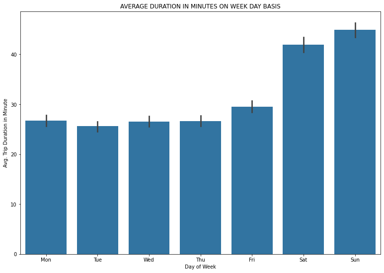

```python
plt.figure(figsize=(13, 9))
sb.barplot(data=data, x='week_name', y='duration', color=base_color, order= weekday);
plt.xlabel('Day of Week');
plt.ylabel('Avg. Trip Duration in Minute')
plt.title('AVERAGE DURATION IN MINUTES ON WEEK DAY BASIS')
```

> During Sundays the average minutes is more than 40 minutes.

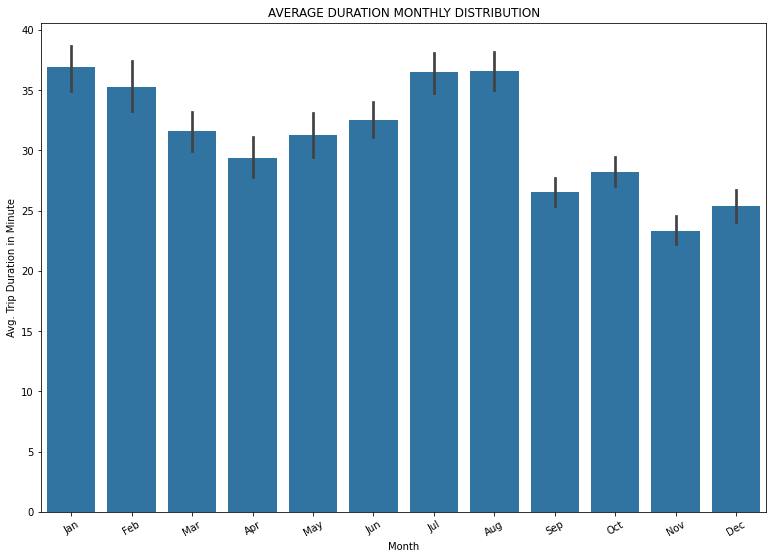

```python
plt.figure(figsize=(13, 9))
sb.barplot(data=data, x='start_month', y='duration', color=base_color);
plt.xticks(rotation=30);
plt.xlabel('Month');
plt.ylabel('Avg. Trip Duration in Minute');
plt.title('AVERAGE DURATION MONTHLY DISTRIBUTION')
```

> The highest average minutes were in January, July and August.

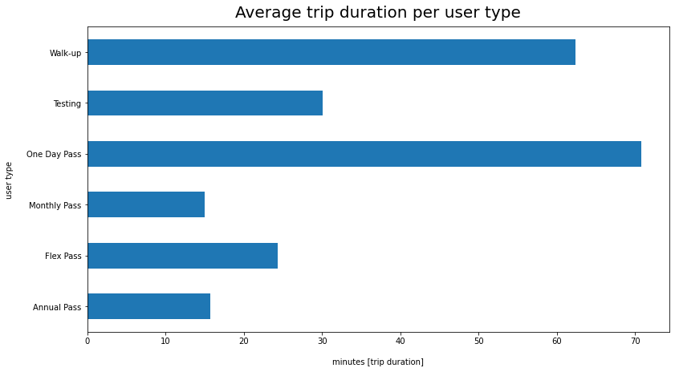

```python
ax = data.groupby('passholder_type')['duration'].mean().plot(kind='barh', color=base_color, figsize=(13,7))
ax.set_title('Average trip duration per user type', fontsize=20, y=1.015)
ax.set_ylabel('user type', labelpad=16)
ax.set_xlabel('minutes [trip duration]', labelpad=16)
```

> One day passholder has an average minutes of 70 minutes.

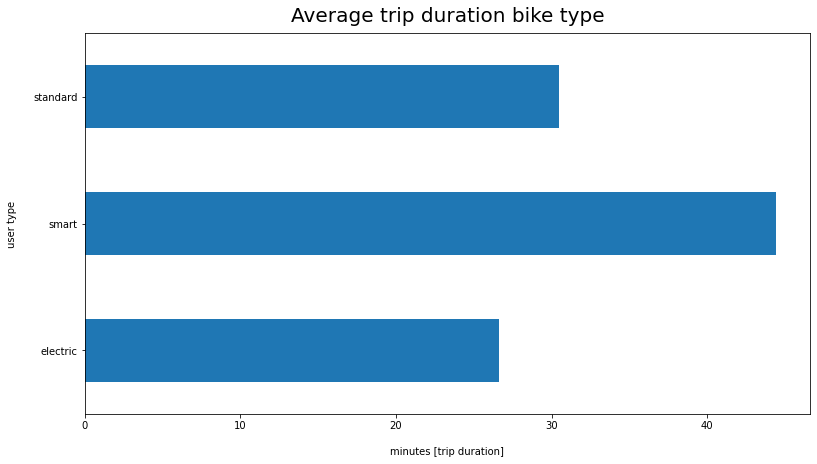

```python
ax = data.groupby('bike_type')['duration'].mean().plot(kind='barh', color=base_color, figsize=(13,7))
ax.set_title('Average trip duration bike type', fontsize=20, y=1.015)
ax.set_ylabel('user type', labelpad=16)
ax.set_xlabel('minutes [trip duration]', labelpad=16)
```

> The average minutes by smart bike is more than 40 minutes.

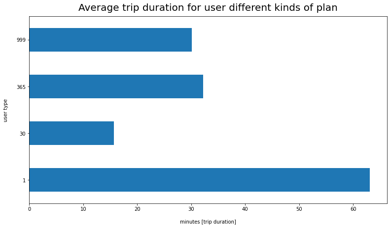

```python
ax = data.groupby('plan_duration')['duration'].mean().plot(kind='barh', color=base_color, figsize=(13,7))
ax.set_title('Average trip duration for user different kinds of plan', fontsize=20, y=1.015)
ax.set_ylabel('user type', labelpad=16)
ax.set_xlabel('minutes [trip duration]', labelpad=16)
```

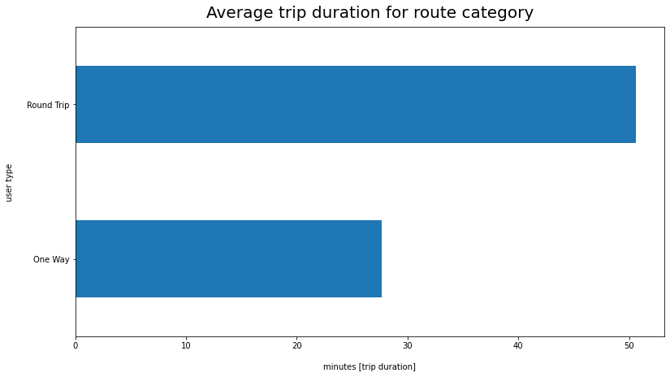

```python
ax = data.groupby('trip_route_category')['duration'].mean().plot(kind='barh', color=base_color, figsize=(13,7))
ax.set_title('Average trip duration for route category', fontsize=20, y=1.015)
ax.set_ylabel('user type', labelpad=16)
ax.set_xlabel('minutes [trip duration]', labelpad=16)
```

> The round trip takes about 50 average minutes.

## Multivariate Exploration

```python
ap = data.query('passholder_type == "Annual Pass"')
ap_counts= ap.groupby(['week_name','start_month']).size()
ap_counts= ap_counts.reset_index(name='count')
ap_counts = ap_counts.pivot(index='week_name', columns='start_month', values='count')
```

```python
fp = data.query('passholder_type == "Flex Pass"')
fp_counts= fp.groupby(['week_name','start_month']).size()
fp_counts= fp_counts.reset_index(name='count')
fp_counts = fp_counts.pivot(index='week_name', columns='start_month', values='count')
```

```python
mp = data.query('passholder_type == "Monthly Pass"')
mp_counts= mp.groupby(['week_name','start_month']).size()
mp_counts= mp_counts.reset_index(name='count')
mp_counts = mp_counts.pivot(index='week_name', columns='start_month', values='count')
```

```python
op = data.query('passholder_type == "One Day Pass"')
op_counts= op.groupby(['week_name','start_month']).size()
op_counts= op_counts.reset_index(name='count')
op_counts = op_counts.pivot(index='week_name', columns='start_month', values='count')
```

```python
test = data.query('passholder_type == "Testing"')
test_counts= test.groupby(['week_name','start_month']).size()
test_counts= test_counts.reset_index(name='count')
test_counts = test_counts.pivot(index='week_name', columns='start_month', values='count')
```

```python
walk = data.query('passholder_type == "Walk-up"')
walk_counts= walk.groupby(['week_name','start_month']).size()
walk_counts= walk_counts.reset_index(name='count')
walk_counts = walk_counts.pivot(index='week_name', columns='start_month', values='count')
```

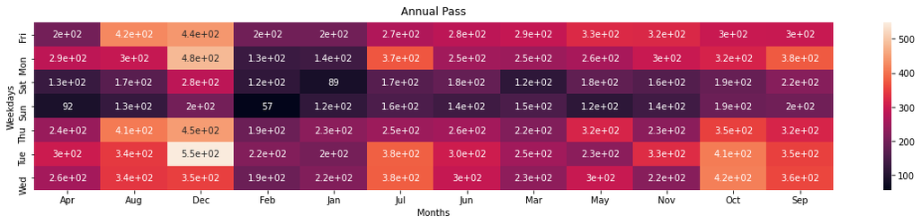

```python
plt.figure(figsize = (20,20))

plt.subplot(5,1,1)
sb.heatmap(ap_counts, annot=True)
plt.title("Annual Pass", y=1.015)
plt.xlabel('Months')
plt.ylabel('Weekdays')
```

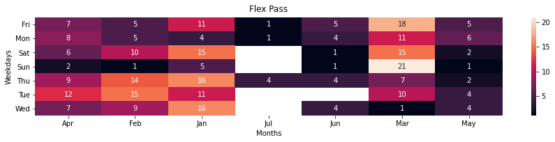

```python
plt.figure(figsize = (15,15))
plt.subplot(5,1,1)
sb.heatmap(fp_counts,annot=True)
plt.title("Flex Pass", y=1.015)
plt.xlabel('Months')
plt.ylabel('Weekdays')
```

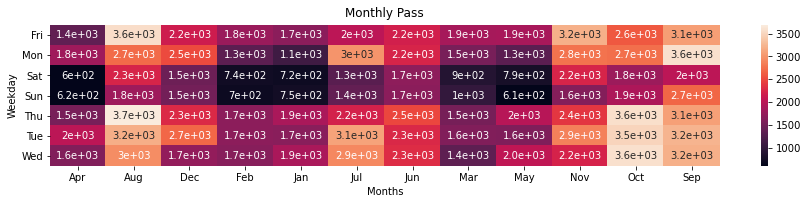

```python
plt.figure(figsize = (15,15))
plt.subplot(5,1,1)
sb.heatmap(mp_counts,annot=True)
plt.title("Monthly Pass", y=1.015)
plt.xlabel('Months')
plt.ylabel('Weekday')
```

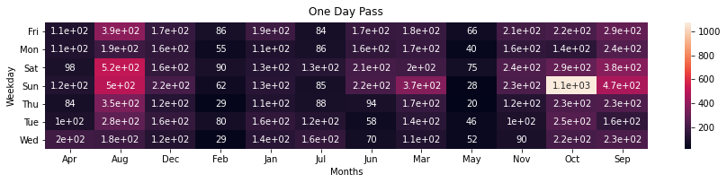

```python
plt.figure(figsize = (15,15))
plt.subplot(5,1,1)
sb.heatmap(op_counts,annot=True)
plt.title("One Day Pass", y=1.015)
plt.xlabel('Months')
plt.ylabel('Weekday')
```

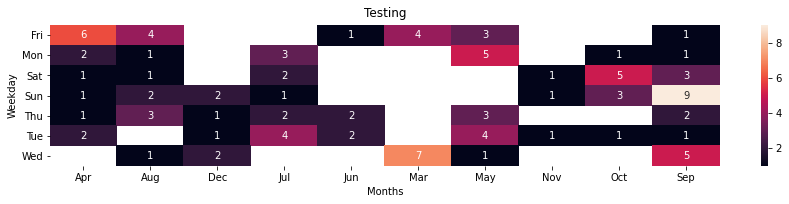

```python
plt.figure(figsize = (15,15))
plt.subplot(5,1,1)
sb.heatmap(test_counts,annot=True)
plt.title("Testing", y=1.015)
plt.xlabel('Months')
plt.ylabel('Weekday')
```

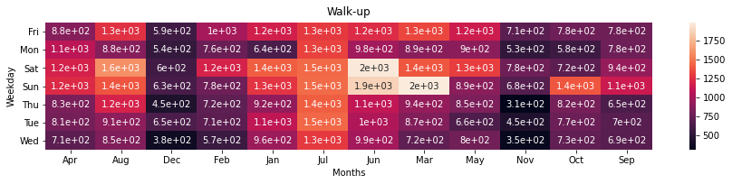

```python
plt.figure(figsize = (15,15))
plt.subplot(5,1,1)
sb.heatmap(walk_counts,annot=True)
plt.title("Walk-up", y=1.015)
plt.xlabel('Months')
plt.ylabel('Weekday')
```

> Heatmaps were used to observe the relationship between months, weekday and passholder types